# Notebook

## Question 1

**Find the expected value of a mixed distribution for the data based on the estiamted mixed model**.

The mean of the data = mean(faithful$waiting) = 70.897

## Question 2

**What is the variance of a mixed distribution $\sum_i \lambda_i f_i(x)$ given the variance $\sigma_i^2$ and mean $\mu_i$ for each $f_i(x)$?**

\mathrm{Var}(X) = \sum_i \lambda_i \mathbb{E}(X_i^2) - \Big(\sum_i \lambda_i \mu_i\Big)^2 = \sum_i \lambda_i(\sigma_i^2+\mu_i^2) - \Big(\sum_i \lambda_i \mu_i\Big)^2. $$

```r
#The mean of the data
mean(faithful$waiting)

#The theortical mean based on the estimated mixed distribution
0.36*54.61 + 0.64*80.9
```

70.8970588235294

71.4356

```r
#Find the variance of the data
var(faithful$waiting)

#Find the theoritical variance based on the mixed distribution
#$lambda
#[1] 0.3608868 0.6391132
#$mu
#[1] 54.61489 80.09109
#$sigma
#[1] 5.871240 5.867719

0.36*(5.871240^2 + 54.61489^2) + 0.64*(5.86^2 + 80.01^2) - (0.36*54.61 + 0.64*80.9)^2
```

184.823312350771

102.169221425894

#### Kenerl density estimation (nonparametric estimate)

Given $n$ observations $x_1, x_2, \ldots, x_n$, the kernel density estimator is $$ \hat f(x)=\frac{1}{nh}\sum_{i=1}^{n} K\!\left(\frac{x-x_i}{h}\right), $$ where

- $h>0$ is the **bandwidth** (smoothing parameter),
- $K(\cdot)$ is the **kernel function**, satisfying

$$ K(u)\ge 0,\qquad \int_{-\infty}^{\infty}K(u)\,du=1, $$

and typically $K(u)$ is **symmetric about 0**, i.e., $K(u)=K(-u)$.

### Commonly used kernels

1. **Standard normal (Gaussian)** kernel:

$$ K(u)=\phi(u)=\frac{1}{\sqrt{2\pi}}e^{-u^2/2}. $$

2. **Uniform (rectangle)** kernel:

$$ K(u)=\frac{1}{2}\mathbf{1}(|u|<1). $$

3. **Epanechnikov** kernel:

$$ K(u)=\frac{3}{4}(1-u^2)\mathbf{1}(|u|<1). $$

Why bandwidth matters

The bandwidth $h$ is critical in KDE, similar to the **bin width** in a histogram.

1. **If $h$ is extremely large**, then $\hat f(x)$ becomes overly smooth and may look almost flat (close to a uniform density over the data range).

Example: if the data are from $N(0,5)$, most observations lie roughly in $[-30,30]$. If $h=10000$, then all points contribute almost equally for any $x$, making the KDE nearly constant.

2. **If $h$ is too small**, then $\hat f(x)$ becomes very wiggly and can overfit, producing many spurious peaks.
3. **If $h$ is appropriate**, then $\hat f(x)$ provides a smooth estimate that captures the main shape of the underlying distribution.

#### Bandwidth selection

Choosing $h$ is one of the most important steps in KDE. A widely used rule of thumb is **Silverman’s rule of thumb**: $$ \hat h = 1.06\,\hat\sigma\,n^{-1/5}, $$ where $\hat\sigma$ is the sample standard deviation.

High dimensional case:

$$ \hat f(\mathbf{x}) = \frac{1}{n\,h_1 h_2 \cdots h_d} \sum_{i=1}^{n} K\!\left( \frac{x_1-x_{i1}}{h_1}, \frac{x_2-x_{i2}}{h_2}, \ldots, \frac{x_d-x_{id}}{h_d} \right), $$

where

- $\mathbf{x}=(x_1,\ldots,x_d)$ is a $d$-dimensional point,
- $\mathbf{x}_i=(x_{i1},\ldots,x_{id})$ is the $i$-th observation,
- $h_1,\ldots,h_d$ are bandwidths (one per dimension),
- $K(\cdot)$ is a multivariate kernel (often built from a product of 1D kernels).

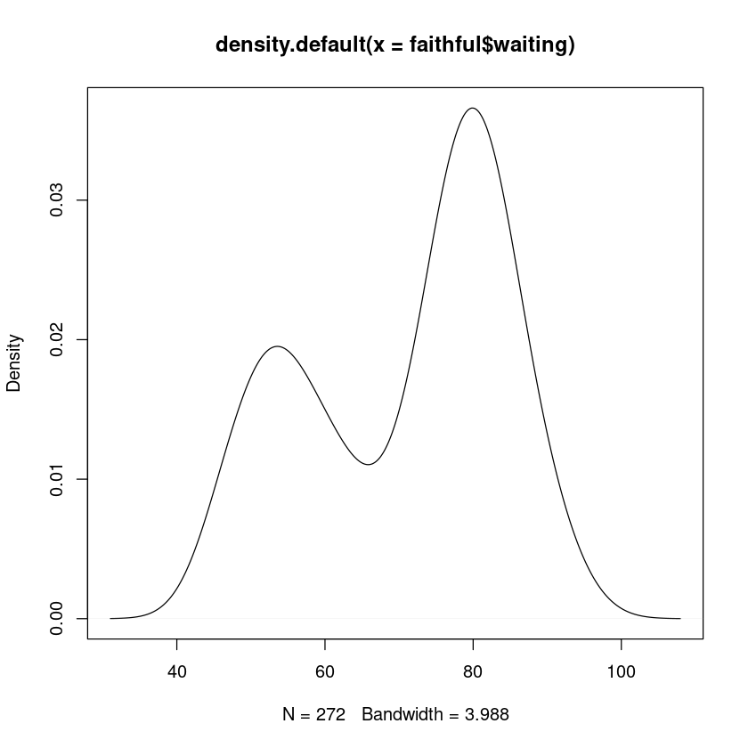

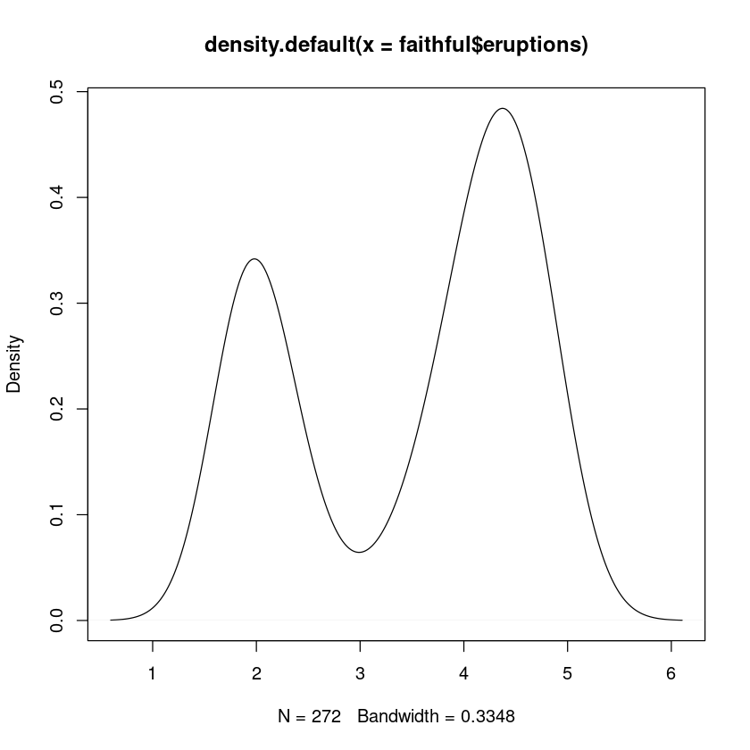

[figure not shown]

```r
#Make a kernel density estimation for "waiting"

# Kernel density estimate
d = density(faithful$waiting)   # x is a numeric vector
plot(d)

#the kernel estimation for eruptions
d1 = density(faithful$eruptions)
plot(d1)

#hist(faithful$eruptions)
```

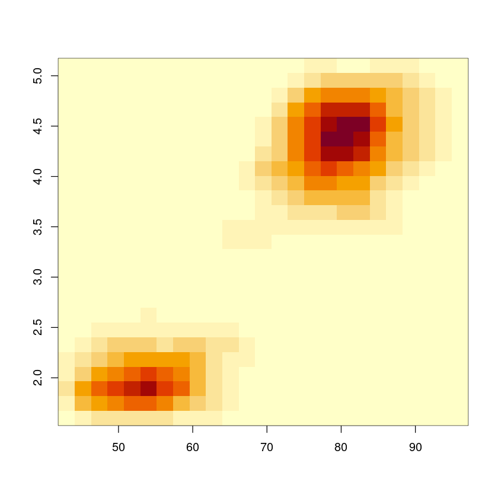

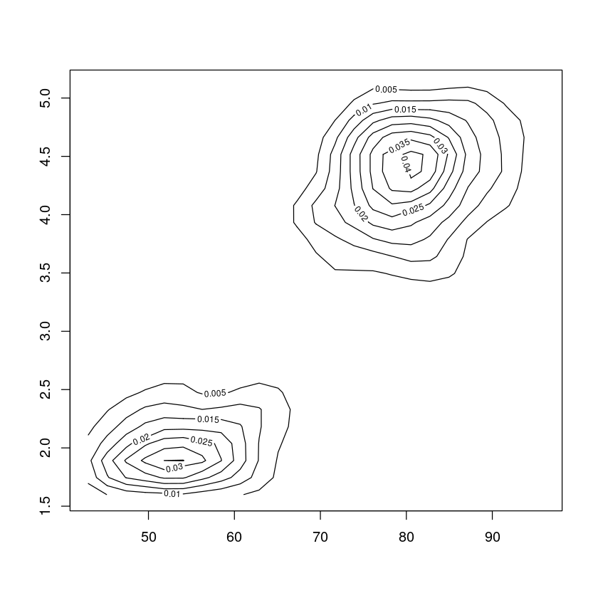

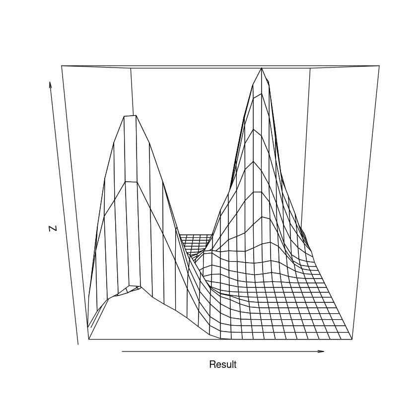

```r
#What is a bivariate distributon for both "eruptions" and "waiting"


library(MASS)

#bandwith selection
h1 <- width.SJ(faithful$waiting)
h2 <- width.SJ(faithful$eruptions)

Result <- kde2d(faithful$waiting, faithful$eruptions, h = c(h1, h2))

image(Result)     # heatmap view
contour(Result)   # contour lines
persp(Result)     # 3D surface plot
```